# Part II - Communicate Data Findings: Ford GoBike System Data

by (TIMILEYIN AKINTILO)

## Investigation Overview

For the presentation, I will focus on just the relationship between ride distance and ride duration. Since both of them are quantitative variables, we will visualize their relationship on a scattered plot. As a result of the presence of outliers and also to avoid overplotting, an axis limit beteen 0 and 10km was set for the x axis. Jitters and transparancy settings will also be employed to yield the best output.

Afterwards, I will look into the relationship between member birth year, ride duration and member gender. The relationship between the three variables will be visualized on a scattered plot using the regplot method. Jitters and transparancy settings will also be employed to yield the best output.

Lastly, I will examine the relationship between member birth year, bikeshare for all trip and ride duration. The relationship between the three variables also will be visualized on a scattered plot using the regplot method. Jitters and transparancy settings will also be employed to yield the best output.

## Dataset Overview

This data set includes information about individual rides made in a bike-sharing system covering the greater San Francisco Bay area. The dataset used for the analysis is available here https://video.udacity-data.com/topher/2020/October/5f91cf38_201902-fordgobike-tripdata/201902-fordgobike-tripdata.csv.

## (Visualization 1)

Firstly, I will focus on the relationship between ride distance and ride duration. Since both of them are quantitative variables, we will visualize their relationship on a scattered plot. As a result of the presence of outliers and also to avoid overplotting, an axis limit beteen 0 and 10km was set for the x axis. Jitters and transparancy settings will also be employed to yield the best output.

```
Text(0,0.5,'Duration_sec(seconds)')
```

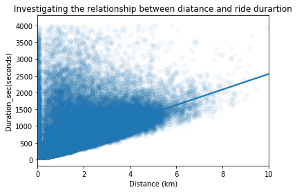

As expected, there is a positive correlation between distance and duration. The farther the distance, the more the ride duration. Most distance for most rides are below 4km and most rides takes below 2000 seconds

## (Visualization 2)

Now, I will look into the relationship between member birth year, ride duration and member gender. The relationship between the three variables will be visualized on a scattered plot using the regplot method. Jitters and transparancy settings will also be employed to yield the best output.

```
Text(0,0.5,'Duration_sec(seconds)')
```

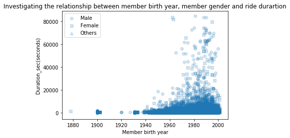

As seen on the plot, most of the members are born 1940 and 2000, only few were born before 1940. Also, most individuals under the 'other' category have little ride duration mostly below 20000 seconds. Only males and females are seen to have speed ride duration greater than 20000. Futhermore, those males and females having ride duration greater than 20000 were born between 1960 and 2000. Above 20000 seconds there are more of males than females.

## (Visualization 3)

Lastly, I will examine the relationship between member birth year, bikeshare for all trip and ride duration. The relationship between the three variables also will be visualized on a scattered plot using the regplot method. Jitters and transparancy settings will also be employed to yield the best output.

```
Text(0,0.5,'Duration_sec(seconds)')
```

[figure not shown]